```python
import pandas as pd
import numpy as np
import seaborn as sns
import matplotlib.pyplot as plt
```

# 문제1 - 10점

- 수학, 영어 점수의 평균을 구하고, 점수가 높은 순서대로 정렬한 후 결과값으로 **점수가 높은 5명의 점수를 출력**하세요.
- 리스트 순서대로 학생 한 명의 점수입니다.
- hint: for문 사용

```python
english = [84, 76, 86, 90, 73, 85, 81, 71, 89, 100]
math = [72, 76, 86, 71, 69, 96, 74, 83, 87, 68]

# 리스트 값은 주어짐

total = []

'''
for i, j in zip(english, math):
    total.append(i + j)
'''


for i in range(10):
    total.append((english[i] + math[i]) / 2)

total.sort(reverse = True)

print(total[0:5])
```

```
[90.5, 88.0, 86.0, 84.0, 80.5]
```

**채점 기준**

1. for문 사용해서 수학, 영어 점수의 평균을 구했는가?
2. 점수가 높은 순서대로 정렬했는가?
3. 5명의 점수를 출력했는가?

# 문제2 -15점

- 다음은 2022년 7월 26일 오후 2시 기준, 원화 환율입니다. (미국:1309.70$, 유럽연합:1339.30€, 중국:193.84¥, 영국:1579.96£)
- 환전하려는 금액을 입력 받고, 나라를 입력 받아서 환율을 **소수점 2자리**로 출력하세요.
- Hint: 환전 금액과 나라 입력 시 input 함수를, 국가별 환율 계산에는 조건문을 사용하세요.

<답안 예시>

환전 금액(원화):8000

국가 선택(미국/유럽연합/중국/영국):미국

6.11

```python
price=int(input("환전금액(원화): "))
country=input("국가 선택(미국/유럽연합/중국/영국): ")

if country=='미국':
    price_change=price/1309.70
    print('%.2f' %price_change)

elif country=='유럽연합':
    price_change=price/1339.30
    print('%.2f' %price_change)

elif country=='중국':
    price_change=price/193.84
    print('%.2f' %price_change)

elif country=='영국':
    price_change=price/1579.96
    print('%.2f' %price_change)
```

```
환전금액(원화): 8000
국가 선택(미국/유럽연합/중국/영국): 미국
6.11
```

**채점기준**

1. input 함수를 사용해서 환전 금액과 국가 입력을 적절히 수행했는가?
2. if문을 활용해 국가별 환율 계산을 적절히 수행했는가?

# 문제3 - 25점

### 문제 [3-1] - 3점

midwest.csv를 불러와 midwest에 저장하고, 위에서부터 10행까지 출력하시오.

```python
midwest = pd.read_csv('C:/Users/USER-PC/anaconda3/WorkSpace/Doit_Python/Data/midwest.csv')
midwest.head(10)
```

|  | PID | county | state | area | poptotal | popdensity | popwhite | popblack | popamerindian | popasian | ... | percollege | percprof | poppovertyknown | percpovertyknown | percbelowpoverty | percchildbelowpovert | percadultpoverty | percelderlypoverty | inmetro | category |
| --- | --- | --- | --- | --- | --- | --- | --- | --- | --- | --- | --- | --- | --- | --- | --- | --- | --- | --- | --- | --- | --- |
| 0 | 561 | ADAMS | IL | 0.052 | 66090 | 1270.961540 | 63917 | 1702 | 98 | 249 | ... | 19.631392 | 4.355859 | 63628 | 96.274777 | 13.151443 | 18.011717 | 11.009776 | 12.443812 | 0 | AAR |
| 1 | 562 | ALEXANDER | IL | 0.014 | 10626 | 759.000000 | 7054 | 3496 | 19 | 48 | ... | 11.243308 | 2.870315 | 10529 | 99.087145 | 32.244278 | 45.826514 | 27.385647 | 25.228976 | 0 | LHR |
| 2 | 563 | BOND | IL | 0.022 | 14991 | 681.409091 | 14477 | 429 | 35 | 16 | ... | 17.033819 | 4.488572 | 14235 | 94.956974 | 12.068844 | 14.036061 | 10.852090 | 12.697410 | 0 | AAR |
| 3 | 564 | BOONE | IL | 0.017 | 30806 | 1812.117650 | 29344 | 127 | 46 | 150 | ... | 17.278954 | 4.197800 | 30337 | 98.477569 | 7.209019 | 11.179536 | 5.536013 | 6.217047 | 1 | ALU |
| 4 | 565 | BROWN | IL | 0.018 | 5836 | 324.222222 | 5264 | 547 | 14 | 5 | ... | 14.475999 | 3.367680 | 4815 | 82.505140 | 13.520249 | 13.022889 | 11.143211 | 19.200000 | 0 | AAR |
| 5 | 566 | BUREAU | IL | 0.050 | 35688 | 713.760000 | 35157 | 50 | 65 | 195 | ... | 18.904624 | 3.275891 | 35107 | 98.372002 | 10.399635 | 14.158819 | 8.179287 | 11.008586 | 0 | AAR |
| 6 | 567 | CALHOUN | IL | 0.017 | 5322 | 313.058824 | 5298 | 1 | 8 | 15 | ... | 11.917388 | 3.209601 | 5241 | 98.478016 | 15.149781 | 13.787761 | 12.932331 | 21.085271 | 0 | LAR |
| 7 | 568 | CARROLL | IL | 0.027 | 16805 | 622.407407 | 16519 | 111 | 30 | 61 | ... | 16.197121 | 3.055727 | 16455 | 97.917287 | 11.710726 | 17.225462 | 10.027037 | 9.525052 | 0 | AAR |
| 8 | 569 | CASS | IL | 0.024 | 13437 | 559.875000 | 13384 | 16 | 8 | 23 | ... | 14.107649 | 3.206799 | 13081 | 97.350599 | 13.875086 | 17.994784 | 11.914343 | 13.660180 | 0 | AAR |
| 9 | 570 | CHAMPAIGN | IL | 0.058 | 173025 | 2983.189660 | 146506 | 16559 | 331 | 8033 | ... | 41.295808 | 17.757448 | 154934 | 89.544286 | 15.572437 | 14.132234 | 17.562728 | 8.105017 | 1 | HAU |

10 rows × 28 columns

**채점 기준**

1. midwest.csv 파일을 pandas를 이용해 저장했는가?
2. 위에서부터 10행을 출력했는가?

### 문제 [3-2] - 7점

- popasian은 해당 지역의 아시아인 인구, poptotal은 해당 지역의 전체 인구를 나타냅니다.
- midwest 데이터에 '전체 인구 대비 아시아인 인구 백분율' 변수인 percent 열을 추가하세요.

```python
midwest['percent'] = (midwest['popasian']) / midwest['poptotal'] * 100
midwest
```

|  | PID | county | state | area | poptotal | popdensity | popwhite | popblack | popamerindian | popasian | ... | percprof | poppovertyknown | percpovertyknown | percbelowpoverty | percchildbelowpovert | percadultpoverty | percelderlypoverty | inmetro | category | percent |
| --- | --- | --- | --- | --- | --- | --- | --- | --- | --- | --- | --- | --- | --- | --- | --- | --- | --- | --- | --- | --- | --- |
| 0 | 561 | ADAMS | IL | 0.052 | 66090 | 1270.961540 | 63917 | 1702 | 98 | 249 | ... | 4.355859 | 63628 | 96.274777 | 13.151443 | 18.011717 | 11.009776 | 12.443812 | 0 | AAR | 0.376759 |
| 1 | 562 | ALEXANDER | IL | 0.014 | 10626 | 759.000000 | 7054 | 3496 | 19 | 48 | ... | 2.870315 | 10529 | 99.087145 | 32.244278 | 45.826514 | 27.385647 | 25.228976 | 0 | LHR | 0.451722 |
| 2 | 563 | BOND | IL | 0.022 | 14991 | 681.409091 | 14477 | 429 | 35 | 16 | ... | 4.488572 | 14235 | 94.956974 | 12.068844 | 14.036061 | 10.852090 | 12.697410 | 0 | AAR | 0.106731 |
| 3 | 564 | BOONE | IL | 0.017 | 30806 | 1812.117650 | 29344 | 127 | 46 | 150 | ... | 4.197800 | 30337 | 98.477569 | 7.209019 | 11.179536 | 5.536013 | 6.217047 | 1 | ALU | 0.486918 |
| 4 | 565 | BROWN | IL | 0.018 | 5836 | 324.222222 | 5264 | 547 | 14 | 5 | ... | 3.367680 | 4815 | 82.505140 | 13.520249 | 13.022889 | 11.143211 | 19.200000 | 0 | AAR | 0.085675 |
| ... | ... | ... | ... | ... | ... | ... | ... | ... | ... | ... | ... | ... | ... | ... | ... | ... | ... | ... | ... | ... | ... |
| 432 | 3048 | WAUKESHA | WI | 0.034 | 304715 | 8962.205880 | 298313 | 1096 | 672 | 2699 | ... | 7.667090 | 299802 | 98.387674 | 3.121060 | 3.785820 | 2.590061 | 4.085479 | 1 | HLU | 0.885746 |
| 433 | 3049 | WAUPACA | WI | 0.045 | 46104 | 1024.533330 | 45695 | 22 | 125 | 92 | ... | 3.138596 | 44412 | 96.330036 | 8.488697 | 10.071411 | 6.953799 | 10.338641 | 0 | AAR | 0.199549 |
| 434 | 3050 | WAUSHARA | WI | 0.037 | 19385 | 523.918919 | 19094 | 29 | 70 | 43 | ... | 2.620907 | 19163 | 98.854785 | 13.786985 | 20.050708 | 11.695784 | 11.804558 | 0 | AAR | 0.221821 |
| 435 | 3051 | WINNEBAGO | WI | 0.035 | 140320 | 4009.142860 | 136822 | 697 | 685 | 1728 | ... | 5.659847 | 133950 | 95.460376 | 8.804031 | 10.592031 | 8.660587 | 6.661094 | 1 | HAU | 1.231471 |
| 436 | 3052 | WOOD | WI | 0.048 | 73605 | 1533.437500 | 72157 | 90 | 481 | 722 | ... | 4.583725 | 72685 | 98.750085 | 8.525831 | 11.162997 | 7.375656 | 7.882918 | 0 | AAR | 0.980912 |

437 rows × 29 columns

**채점 기준**

1. percent 열 값을 올바르게 계산했는가?
2. midwest에 percent 열이 추가되었는가?

### 문제 [3-3] - 3점

- percent 열의 값을 내림차순으로 정렬하세요.

```python
midwest.sort_values('percent', ascending = False)
midwest
```

|  | PID | county | state | area | poptotal | popdensity | popwhite | popblack | popamerindian | popasian | ... | percprof | poppovertyknown | percpovertyknown | percbelowpoverty | percchildbelowpovert | percadultpoverty | percelderlypoverty | inmetro | category | percent |
| --- | --- | --- | --- | --- | --- | --- | --- | --- | --- | --- | --- | --- | --- | --- | --- | --- | --- | --- | --- | --- | --- |
| 0 | 561 | ADAMS | IL | 0.052 | 66090 | 1270.961540 | 63917 | 1702 | 98 | 249 | ... | 4.355859 | 63628 | 96.274777 | 13.151443 | 18.011717 | 11.009776 | 12.443812 | 0 | AAR | 0.376759 |
| 1 | 562 | ALEXANDER | IL | 0.014 | 10626 | 759.000000 | 7054 | 3496 | 19 | 48 | ... | 2.870315 | 10529 | 99.087145 | 32.244278 | 45.826514 | 27.385647 | 25.228976 | 0 | LHR | 0.451722 |
| 2 | 563 | BOND | IL | 0.022 | 14991 | 681.409091 | 14477 | 429 | 35 | 16 | ... | 4.488572 | 14235 | 94.956974 | 12.068844 | 14.036061 | 10.852090 | 12.697410 | 0 | AAR | 0.106731 |
| 3 | 564 | BOONE | IL | 0.017 | 30806 | 1812.117650 | 29344 | 127 | 46 | 150 | ... | 4.197800 | 30337 | 98.477569 | 7.209019 | 11.179536 | 5.536013 | 6.217047 | 1 | ALU | 0.486918 |
| 4 | 565 | BROWN | IL | 0.018 | 5836 | 324.222222 | 5264 | 547 | 14 | 5 | ... | 3.367680 | 4815 | 82.505140 | 13.520249 | 13.022889 | 11.143211 | 19.200000 | 0 | AAR | 0.085675 |
| ... | ... | ... | ... | ... | ... | ... | ... | ... | ... | ... | ... | ... | ... | ... | ... | ... | ... | ... | ... | ... | ... |
| 432 | 3048 | WAUKESHA | WI | 0.034 | 304715 | 8962.205880 | 298313 | 1096 | 672 | 2699 | ... | 7.667090 | 299802 | 98.387674 | 3.121060 | 3.785820 | 2.590061 | 4.085479 | 1 | HLU | 0.885746 |
| 433 | 3049 | WAUPACA | WI | 0.045 | 46104 | 1024.533330 | 45695 | 22 | 125 | 92 | ... | 3.138596 | 44412 | 96.330036 | 8.488697 | 10.071411 | 6.953799 | 10.338641 | 0 | AAR | 0.199549 |
| 434 | 3050 | WAUSHARA | WI | 0.037 | 19385 | 523.918919 | 19094 | 29 | 70 | 43 | ... | 2.620907 | 19163 | 98.854785 | 13.786985 | 20.050708 | 11.695784 | 11.804558 | 0 | AAR | 0.221821 |
| 435 | 3051 | WINNEBAGO | WI | 0.035 | 140320 | 4009.142860 | 136822 | 697 | 685 | 1728 | ... | 5.659847 | 133950 | 95.460376 | 8.804031 | 10.592031 | 8.660587 | 6.661094 | 1 | HAU | 1.231471 |
| 436 | 3052 | WOOD | WI | 0.048 | 73605 | 1533.437500 | 72157 | 90 | 481 | 722 | ... | 4.583725 | 72685 | 98.750085 | 8.525831 | 11.162997 | 7.375656 | 7.882918 | 0 | AAR | 0.980912 |

437 rows × 29 columns

**채점 기준**

1. percent 열의 값이 제대로 정렬되었는가? (percent 값이 틀리더라도 정렬이 제대로 되어 있다면 정답 처리)

### 문제 [3-4] - 6점

- percent를 아래의 분류 기준에 따라 새로운 변수를 추가해주시고, 각 분류에 해당하는 지역이 몇 개인지 확인해보시오.
- large: 0.9% 이상 / middle: 0.4~0.9% 미만 / small: 0.4% 미만

```python
midwest['grade'] = np.where(midwest['percent'] >= 0.9, 'large',
                   np.where(midwest['percent'] >= 0.4, 'middle', 'small'))

midwest.groupby('grade').agg(n = ('grade', 'count'))
```

| grade | n |
| --- | --- |
| large | 53 |
| middle | 96 |
| small | 288 |

**채점 기준**

1. grade를 np.where을 통해 잘 분류했는가?
2. 각 분류에 해당하는 지역을 잘 나타냈는가?

### 문제 [3-5] - 6점

- county가 'SCOTT'인 경우와 country가 'PIATT'인 경우의 poptotal 열의 평균을 각각 구해서 출력하세요.
- hint: query 함수와 mean 함수 사용

```python
SCOTT = midwest.query('county == "SCOTT"')['poptotal'].mean()
PIATT = midwest.query('county == "PIATT"')['poptotal'].mean()
print(SCOTT, PIATT)
```

```
13317.5 15548.0
```

**채점 기준**

1. SCOTT와 PIATT인 경우를 각각 잘 분류했는가?
2. 평균값을 잘 구했는가?

# 문제4 - 50점

다음 데이터를 사용하여 각 문항에 답하세요.

```python
titanic=sns.load_dataset('titanic')
titanic.head()
```

|  | survived | pclass | sex | age | sibsp | parch | fare | embarked | class | who | adult_male | deck | embark_town | alive | alone |
| --- | --- | --- | --- | --- | --- | --- | --- | --- | --- | --- | --- | --- | --- | --- | --- |
| 0 | 0 | 3 | male | 22.0 | 1 | 0 | 7.2500 | S | Third | man | True | NaN | Southampton | no | False |
| 1 | 1 | 1 | female | 38.0 | 1 | 0 | 71.2833 | C | First | woman | False | C | Cherbourg | yes | False |
| 2 | 1 | 3 | female | 26.0 | 0 | 0 | 7.9250 | S | Third | woman | False | NaN | Southampton | yes | True |
| 3 | 1 | 1 | female | 35.0 | 1 | 0 | 53.1000 | S | First | woman | False | C | Southampton | yes | False |
| 4 | 0 | 3 | male | 35.0 | 0 | 0 | 8.0500 | S | Third | man | True | NaN | Southampton | no | True |

### 문제 [4-1] - 8점

titanic에서 열별 결측치 여부를 확인하고, 결측치가 존재한다면 결측치를 해당 열의 평균값으로 채우세요.

```python
titanic.isnull().sum()
titanic['age'].fillna(titanic['age'].mean(),inplace=True)
titanic
```

|  | survived | pclass | sex | age | sibsp | parch | fare | embarked | class | who | adult_male | deck | embark_town | alive | alone |
| --- | --- | --- | --- | --- | --- | --- | --- | --- | --- | --- | --- | --- | --- | --- | --- |
| 0 | 0 | 3 | male | 22.000000 | 1 | 0 | 7.2500 | S | Third | man | True | NaN | Southampton | no | False |
| 1 | 1 | 1 | female | 38.000000 | 1 | 0 | 71.2833 | C | First | woman | False | C | Cherbourg | yes | False |
| 2 | 1 | 3 | female | 26.000000 | 0 | 0 | 7.9250 | S | Third | woman | False | NaN | Southampton | yes | True |
| 3 | 1 | 1 | female | 35.000000 | 1 | 0 | 53.1000 | S | First | woman | False | C | Southampton | yes | False |
| 4 | 0 | 3 | male | 35.000000 | 0 | 0 | 8.0500 | S | Third | man | True | NaN | Southampton | no | True |
| ... | ... | ... | ... | ... | ... | ... | ... | ... | ... | ... | ... | ... | ... | ... | ... |
| 886 | 0 | 2 | male | 27.000000 | 0 | 0 | 13.0000 | S | Second | man | True | NaN | Southampton | no | True |
| 887 | 1 | 1 | female | 19.000000 | 0 | 0 | 30.0000 | S | First | woman | False | B | Southampton | yes | True |
| 888 | 0 | 3 | female | 29.699118 | 1 | 2 | 23.4500 | S | Third | woman | False | NaN | Southampton | no | False |
| 889 | 1 | 1 | male | 26.000000 | 0 | 0 | 30.0000 | C | First | man | True | C | Cherbourg | yes | True |
| 890 | 0 | 3 | male | 32.000000 | 0 | 0 | 7.7500 | Q | Third | man | True | NaN | Queenstown | no | True |

891 rows × 15 columns

**채점 기준**

1. 열별 결측지 여부를 확인했는가?
2. fillna 함수를 통해 age 열의 결측치 값을 평균값으로 채웠는가?

### 문제 [4-2] - 점수 7점

titanic의 각 열에서 결측치가 아닌 데이터가 250개 이상이 되지 않는 경우, 이 열을 삭제한 후 df에 저장하세요.

```python
df=titanic.dropna(axis=1,thresh=250)
df
```

|  | survived | pclass | sex | age | sibsp | parch | fare | embarked | class | who | adult_male | embark_town | alive | alone |
| --- | --- | --- | --- | --- | --- | --- | --- | --- | --- | --- | --- | --- | --- | --- |
| 0 | 0 | 3 | male | 22.000000 | 1 | 0 | 7.2500 | S | Third | man | True | Southampton | no | False |
| 1 | 1 | 1 | female | 38.000000 | 1 | 0 | 71.2833 | C | First | woman | False | Cherbourg | yes | False |
| 2 | 1 | 3 | female | 26.000000 | 0 | 0 | 7.9250 | S | Third | woman | False | Southampton | yes | True |
| 3 | 1 | 1 | female | 35.000000 | 1 | 0 | 53.1000 | S | First | woman | False | Southampton | yes | False |
| 4 | 0 | 3 | male | 35.000000 | 0 | 0 | 8.0500 | S | Third | man | True | Southampton | no | True |
| ... | ... | ... | ... | ... | ... | ... | ... | ... | ... | ... | ... | ... | ... | ... |
| 886 | 0 | 2 | male | 27.000000 | 0 | 0 | 13.0000 | S | Second | man | True | Southampton | no | True |
| 887 | 1 | 1 | female | 19.000000 | 0 | 0 | 30.0000 | S | First | woman | False | Southampton | yes | True |
| 888 | 0 | 3 | female | 29.699118 | 1 | 2 | 23.4500 | S | Third | woman | False | Southampton | no | False |
| 889 | 1 | 1 | male | 26.000000 | 0 | 0 | 30.0000 | C | First | man | True | Cherbourg | yes | True |
| 890 | 0 | 3 | male | 32.000000 | 0 | 0 | 7.7500 | Q | Third | man | True | Queenstown | no | True |

891 rows × 14 columns

**채점 기준**

1. dropna 함수의 threshold 값을 잘 입력해 deck 열을 삭제하여 이를 df에 저장했는가?

### 문제 [4-3] - 5점

- 수치형 데이터의 열별 분포를 간략히 요약해 나타내세요.
- 평균, 최댓값, 사분위수 등

```python
titanic.describe()
```

|  | survived | pclass | age | sibsp | parch | fare |
| --- | --- | --- | --- | --- | --- | --- |
| count | 891.000000 | 891.000000 | 891.000000 | 891.000000 | 891.000000 | 891.000000 |
| mean | 0.383838 | 2.308642 | 29.699118 | 0.523008 | 0.381594 | 32.204208 |
| std | 0.486592 | 0.836071 | 13.002015 | 1.102743 | 0.806057 | 49.693429 |
| min | 0.000000 | 1.000000 | 0.420000 | 0.000000 | 0.000000 | 0.000000 |
| 25% | 0.000000 | 2.000000 | 22.000000 | 0.000000 | 0.000000 | 7.910400 |
| 50% | 0.000000 | 3.000000 | 29.699118 | 0.000000 | 0.000000 | 14.454200 |
| 75% | 1.000000 | 3.000000 | 35.000000 | 1.000000 | 0.000000 | 31.000000 |
| max | 1.000000 | 3.000000 | 80.000000 | 8.000000 | 6.000000 | 512.329200 |

**채점 기준**

1. describe 함수, 혹은 그 외의 방법을 통해 데이터의 열별 분포를 적절히 나타내었는가?

### 문제 [4-4] - 6점

titanic에서 sex와 pclass 별 생존율을 구하세요.

```python
titanic.groupby(['sex','pclass'])['survived'].mean()
```

```
sex     pclass
female  1         0.968085
        2         0.921053
        3         0.500000
male    1         0.368852
        2         0.157407
        3         0.135447
Name: survived, dtype: float64
```

**채점 기준**

1. groupby 함수를 통해 sex와 pclass 별 생존율 계산을 올바르게 수행했는가?

### 문제 [4-5] - 8점

- pclass 별 사망과 생존 수치를 막대그래프로 나타내세요.
- sex 별 사망과 생존 수치를 막대그래프로 나타내세요.
- hint: countplot 함수 사용

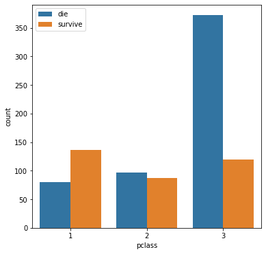

```python
fig,ax=plt.subplots(figsize=(6,6)) #이 문장은 문제에 주어짐

sns.countplot(data=titanic, x='pclass', hue='survived')

labels=['die','survive']
ax.legend(labels=labels)
plt.show()
```

**채점 기준**

1. countplot 함수를 통해 pclass별 사망과 생존 수치를 막대 그래프로 적절히 나타내었는가?
2. 정답지에는 label 값을 0과 1이 아닌 die와 survive로 바꿨는데, 이는 필수사항은 아니며 막대 그래프로 pclass-사망/생존 관계를 나타낸 것을 우선적으로 평가.

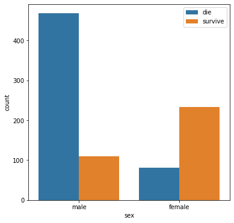

```python
fig,ax=plt.subplots(figsize=(6,6)) #이 문장은 문제에 주어짐

sns.countplot(data=titanic, x='sex', hue='survived')

labels=['die','survive']
ax.legend(labels=labels)
plt.show()
```

**채점 기준**

1. countplot 함수를 통해 sex별 사망과 생존 수치를 막대 그래프로 적절히 나타내었는가?
2. 정답지에는 label 값을 0과 1이 아닌 die와 survive로 바꿨는데, 이는 필수사항은 아니며 막대 그래프로 sex-사망/생존 관계를 나타낸 것을 우선적으로 평가.

### 문제 [4-6] - 8점

- titanic에서 age가 20살 이상이면 adult로, 20살 미만이면 child로 나타내는 label열을 추가하세요.
- hint: apply, lambda 함수 사용

```python
titanic["label"] = titanic.apply(lambda x: "adult" if x.age >= 20 else "child", axis=1)
titanic.tail()
```

|  | survived | pclass | sex | age | sibsp | parch | fare | embarked | class | who | adult_male | deck | embark_town | alive | alone | label |
| --- | --- | --- | --- | --- | --- | --- | --- | --- | --- | --- | --- | --- | --- | --- | --- | --- |
| 886 | 0 | 2 | male | 27.000000 | 0 | 0 | 13.00 | S | Second | man | True | NaN | Southampton | no | True | adult |
| 887 | 1 | 1 | female | 19.000000 | 0 | 0 | 30.00 | S | First | woman | False | B | Southampton | yes | True | child |
| 888 | 0 | 3 | female | 29.699118 | 1 | 2 | 23.45 | S | Third | woman | False | NaN | Southampton | no | False | adult |
| 889 | 1 | 1 | male | 26.000000 | 0 | 0 | 30.00 | C | First | man | True | C | Cherbourg | yes | True | adult |
| 890 | 0 | 3 | male | 32.000000 | 0 | 0 | 7.75 | Q | Third | man | True | NaN | Queenstown | no | True | adult |

**채점 기준**

1. lambda와 apply 함수를 사용해 adult와 child로 분류한 label 열을 적절히 추가하였는가?

### 문제 [4-7] - 8점

- titanic에서 pclass, sex, age, sibsp, parch, class 열만 뽑은 후, parch의 값이 0인 행만 titanic1에 저장하세요.
- 이때 새롭게 만들어진 titanic1의 index는 0부터 다시 시작하도록 하세요.
- hint: loc 함수 사용

```python
titanic1 = titanic.loc[titanic.parch==0,['pclass','sex','age','sibsp','parch','class']].reset_index(drop=True)
titanic1
```

|  | pclass | sex | age | sibsp | parch | class |
| --- | --- | --- | --- | --- | --- | --- |
| 0 | 3 | male | 22.0 | 1 | 0 | Third |
| 1 | 1 | female | 38.0 | 1 | 0 | First |
| 2 | 3 | female | 26.0 | 0 | 0 | Third |
| 3 | 1 | female | 35.0 | 1 | 0 | First |
| 4 | 3 | male | 35.0 | 0 | 0 | Third |
| ... | ... | ... | ... | ... | ... | ... |
| 673 | 3 | male | 25.0 | 0 | 0 | Third |
| 674 | 2 | male | 27.0 | 0 | 0 | Second |
| 675 | 1 | female | 19.0 | 0 | 0 | First |
| 676 | 1 | male | 26.0 | 0 | 0 | First |
| 677 | 3 | male | 32.0 | 0 | 0 | Third |

678 rows × 6 columns

**채점 기준**

1. loc 함수를 사용해 특정 열만 뽑아내고 parch의 값이 0인 행만 data에 적절히 저장했는가?
2. 새로 만들어진 titanic1의 index을 0부터 다시 시작하도록 했는가?

# END

## 수고하셨습니다:) 좋은 결과 있기를 바라며, 코딩테스트는 절대적 평가 기준이 아닙니다.